# High Dimensional Data Visualization

Wayne Oldford and Zehao Xu

2021-05-18

## Serialaxes coordinate

Serial axes coordinate is a methodology for visualizing the $p$-dimensional geometry and multivariate data. As the name suggested, all axes are shown in serial. The axes can be a finite $p$ space or transformed to an infinite space (e.g. Fourier transformation).

In the finite $p$ space, all axes can be displayed in parallel which is known as the parallel coordinate; also, all axes can be displayed under a polar coordinate that is often known as the radial coordinate or radar plot. In the infinite space, a mathematical transformation is often applied. More details will be explained in the sub-section `Infinite axes`

A point in Euclidean $p$-space $R^p$ is represented as a polyline in serial axes coordinate, it is found that a point <–> line duality is induced in the Euclidean plane $R^2$ (A. Inselberg and Dimsdale 1990).

Before we start, a couple of things should be noticed:

- In the serial axes coordinate system, no `x` or `y` (even `group`) are required; but other aesthetics, such as `colour`, `fill`, `size`, etc, are accommodated.
- Layer `geom_path` is used to draw the serial lines; layer `geom_histogram`, `geom_quantiles`, and `geom_density` are used to draw the histograms, quantiles (*not `quantile` regression*) and densities. Users can also customize their own layer (i.e. `geom_boxplot`, `geom_violin`, etc) by editing function `add_serialaxes_layers`.

### Finite axes

Suppose we are interested in the data set `iris`. A parallel coordinate chart can be created as followings:

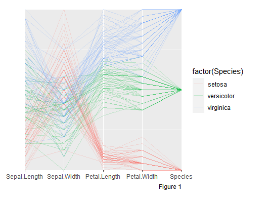

```r
library(ggmulti)
# parallel axes plot
ggplot(iris,
       mapping = aes(
         Sepal.Length = Sepal.Length,
         Sepal.Width = Sepal.Width,
         Petal.Length = Petal.Length,
         Petal.Width = Petal.Width,
         colour = factor(Species))) +
  geom_path(alpha = 0.2)  +
  coord_serialaxes() -> p
p
```

A histogram layer can be displayed by adding layer `geom_histogram`

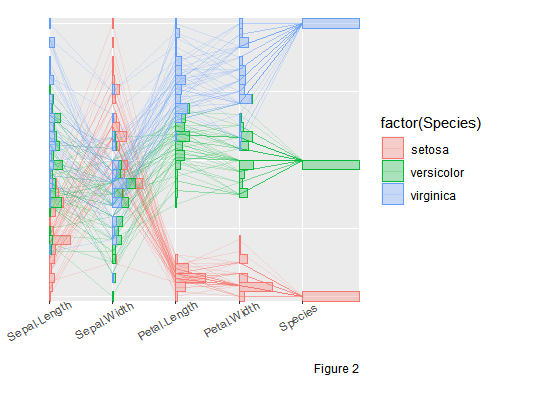

```r
p +
  geom_histogram(alpha = 0.3,
                 mapping = aes(fill = factor(Species))) +
  theme(axis.text.x = element_text(angle = 30, hjust = 0.7))
```

A density layer can be drawn by adding layer `geom_density`

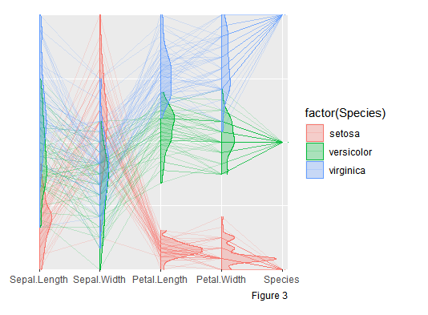

```r
p +
  geom_density(alpha = 0.3,
               mapping = aes(fill = factor(Species)))
```

A parallel coordinate can be converted to radial coordinate by setting `axes.layout = "radial"` in function `coord_serialaxes`.

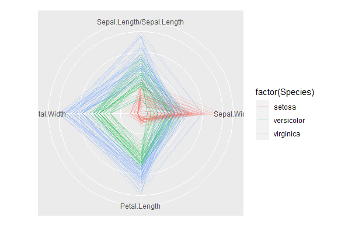

```r
p$coordinates$axes.layout <- "radial"
p
```

Note that: layers, such as `geom_histogram`, `geom_density`, etc, are not implemented in the radial coordinate yet.

### Infinite axes

Andrews (1972) plot is a way to project multi-response observations into a function $f(t)$, by defining $f(t)$ as an inner product of the observed values of responses and orthonormal functions in $t$

$$f_{y_i}(t) = <\mathbf{y}_i, \mathbf{a}_t>$$

where $\mathbf{y}_i$ is the $i$th responses and $\mathbf{a}_t$ is the orthonormal functions under certain interval. Andrew suggests to use the Fourier transformation

$$\mathbf{a}_t = \{\frac{1}{\sqrt{2}}, \sin(t), \cos(t), \sin(2t), \cos(2t), ...\}$$

which are orthonormal on interval $(-\pi, \pi)$. In other word, we can project a $p$ dimensional space to an infinite $(-\pi, \pi)$ space. The following figure illustrates how to construct an “Andrew’s plot.”

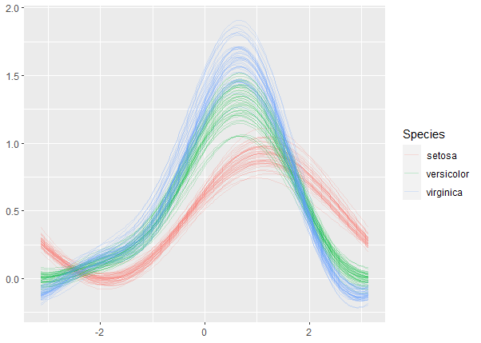

```r
p <- ggplot(iris,
            mapping = aes(Sepal.Length = Sepal.Length,
                          Sepal.Width = Sepal.Width,
                          Petal.Length = Petal.Length,
                          Petal.Width = Petal.Width,
                          colour = Species)) +
  geom_path(alpha = 0.2,
            stat = "dotProduct")  +
  coord_serialaxes()
p
```

A quantile layer can be displayed on top

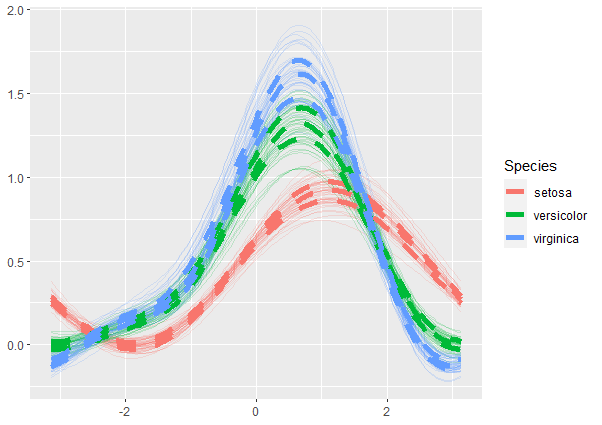

```r
p +
 geom_quantiles(stat = "dotProduct",
                quantiles = c(0.25, 0.5, 0.75),
                size = 2,
                linetype = 2)
```

A couple of things should be noticed:

- mapping aesthetics is used to define the $p$ dimensional space, if not provided, all columns in the dataset ‘iris’ will be transformed. An alternative way to determine the $p$ dimensional space to set parameter `axes.sequence` in each layer or in `coord_serialaxes`.
- To construct a dot product serial axes plot, say Fourier transformation, “Andrew’s plot,” we need to set the parameter `stat` in `geom_path` to “dotProduct.” The default transformation function is the Andrew’s (function `andrews`). Users can customize their own, for example, Tukey suggests the following projected space

  $$\mathbf{a}_t = \{\cos(t), \cos(\sqrt{2}t), \cos(\sqrt{3}t), \cos(\sqrt{5}t), ...\}$$

  where $t \in [0, k\pi]$ (Gnanadesikan 2011).

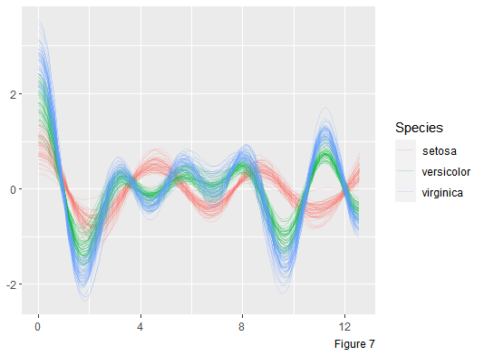

  ```r
  tukey <- function(p = 4, k = 50 * (p - 1), ...) {
    t <- seq(0, p* base::pi, length.out = k)
    seq_k <- seq(p)
    values <- sapply(seq_k,
                     function(i) {
                       if(i == 1) return(cos(t))
                       if(i == 2) return(cos(sqrt(2) * t))
                       Fibonacci <- seq_k[i - 1] + seq_k[i - 2]
                       cos(sqrt(Fibonacci) * t)
                     })
    list(
      vector = t,
      matrix = matrix(values, nrow = p, byrow = TRUE)
    )
  }
  ggplot(iris,
         mapping = aes(Sepal.Length = Sepal.Length,
                       Sepal.Width = Sepal.Width,
                       Petal.Length = Petal.Length,
                       Petal.Width = Petal.Width,
                       colour = Species)) +
    geom_path(alpha = 0.2, stat = "dotProduct", transform = tukey)  +
    coord_serialaxes()
  ```

  Note that: Tukey’s suggestion, element $\mathbf{a}_t$ can “cover” more spheres in $p$ dimensional space, but it is not orthonormal.